# Informe Lab 4

Marco Ramírez, Estuardo Hernández

2022-09-02

## Análisis

Primero presentamos una nube de palabras de la columna “keyword” para ver la frecuancia de cada palabra.

```r
w1
```

[interactive chart not shown]

También se realizó un histograma de las palabras más repetidas para ver como es la dsitribución de la mimsa.

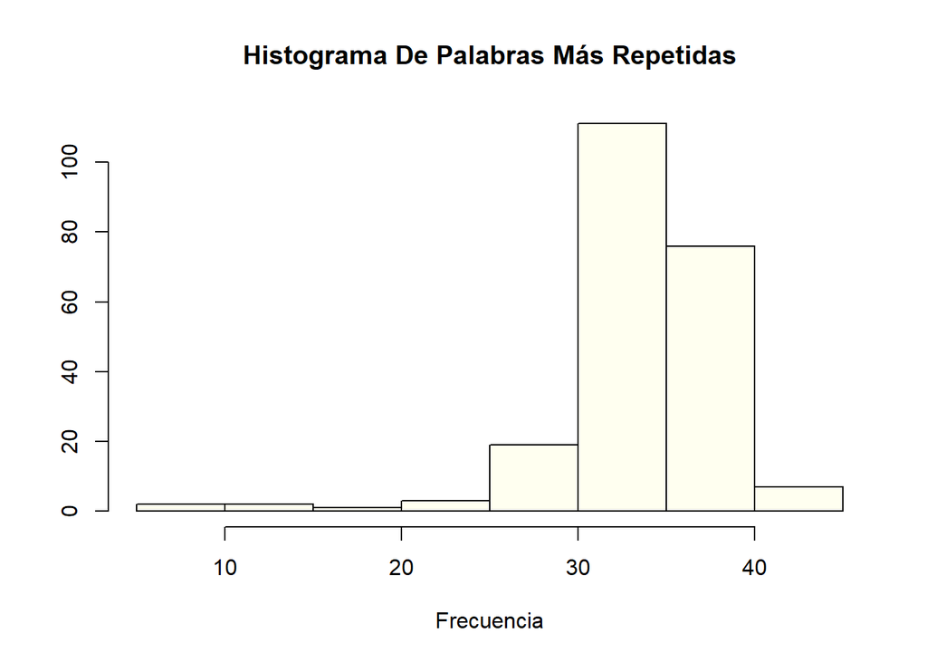

```r
hist(x = freq, main = "Histograma De Palabras Más Repetidas",
     xlab = "Frecuencia", ylab = "",
     col = "ivory")
```

Ahora un gráfico de las palabras que más se repiten en la categoría de “No Disaster”.

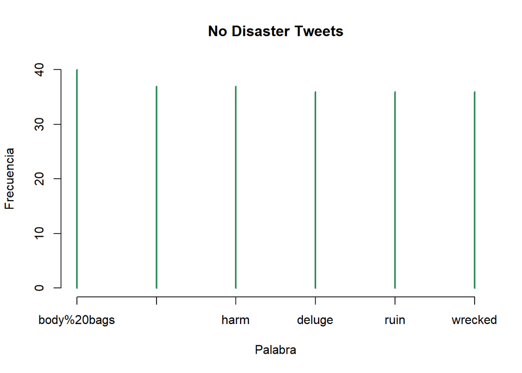

```r
plot(x = h1, main = "No Disaster Tweets",
     xlab = "Palabra", ylab = "Frecuencia",
     col = "seagreen")
```

Vemos que la palabra que más se repite en la categoría de tweets que no tratan de desastres es “body bags”.

Tambien se realizó una nube de palabras de esta misma categoría para ver la frecuencia de cada una.

```r
w2
```

[interactive chart not shown]

Ahora vamos con las palabras que más se repiten en la categoría de “Disaster”, que igual están representadas en un gráfico:

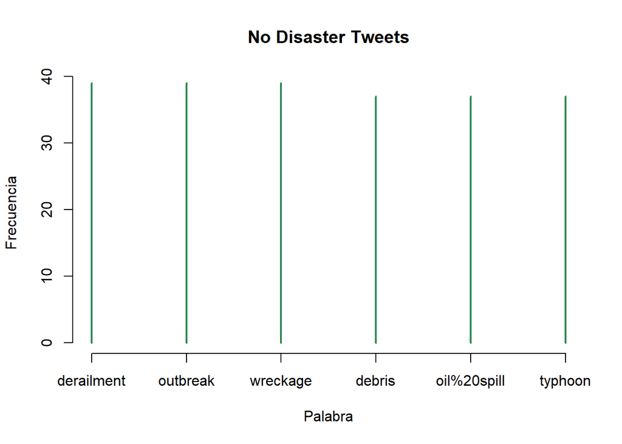

```r
plot(x = h2, main = "No Disaster Tweets",
     xlab = "Palabra", ylab = "Frecuencia",
     col = "seagreen")
```

Tambien se realizó una nube de palabras de esta misma categoría para ver la frecuencia de cada una.

```r
w3
```

[interactive chart not shown]

Por lo menos en las primeras seis palabras de cada categoría no se repite ni una palabra, es decir no hay palabras que estén en ambas categorías.